# Business Problem

This is a dataset from one bank in the United States. Besides usual services, this bank also provides car insurance services. The bank organizes regular campaigns to attract new clients. The bank has potential customers’ data, and bank’s employees call them for advertising available car insurance options.

We are provided with general information about clients (age, job, etc.) as well as more specific information about the current insurance sell campaign (communication, last contact day) and previous campaigns (attributes like previous attempts, outcome).

You have data about 4000 customers who were contacted during the last campaign and for whom the results of campaign (did the customer buy insurance or not) are known.

## Task and Approach:

The task is to predict for 1000 customers who were contacted during the current campaign, whether they will buy car insurance or not.

We will be using **SVM(Support vector machine)** to predict it

### Step 1 : Importing Libraries and Understanding Data

```python
%matplotlib inline
# To make data visualisations display in Jupyter Notebooks
import numpy as np   # linear algebra
import pandas as pd  # Data processing, Input & Output load
import matplotlib.pyplot as plt # Visuvalization & plotting
import datetime
from sklearn.svm import SVC  # supervised learning methods used for classification, regression
import joblib  #Joblib is a set of tools to provide lightweight pipelining in Python (Avoid computing twice the same thing)

from sklearn.model_selection import train_test_split, cross_val_score, GridSearchCV
                                    # GridSearchCV - Implements a “fit” and a “score” method
                                    # train_test_split - Split arrays or matrices into random train and test subsets
                                    # cross_val_score - Evaluate a score by cross-validation
from sklearn.metrics import f1_score, roc_auc_score, recall_score, precision_score, make_scorer, accuracy_score, roc_curve, confusion_matrix, classification_report
                                    # Differnt metrics to evaluate the model
import pandas_profiling as pp   # simple and fast exploratory data analysis of a Pandas Datafram

import warnings   # To avoid warning messages in the code run
warnings.filterwarnings("ignore")
```

## User Defined Functions

```python
def plot_roc_curve(y_train_actual, train_pred_prob, y_test_actual, test_pred_prob, *args):
    '''
    Generate the train & test roc curve
    '''

    AUC_Train = roc_auc_score(y_train_actual, train_pred_prob)
    AUC_Test = roc_auc_score(y_test_actual, test_pred_prob)

    if len(args) == 0:
        print("Train AUC = ", AUC_Train)
        print("Test AUC = ", AUC_Test)
        fpr, tpr, thresholds = roc_curve(y_train_actual, train_pred_prob)
        fpr_tst, tpr_tst, thresholds = roc_curve(y_test_actual, test_pred_prob)
        roc_plot(fpr, tpr, fpr_tst, tpr_tst)

    else:
        AUC_Valid = roc_auc_score(args[0], args[1])
        print("Train AUC = ", AUC_Train)
        print("Test AUC = ", AUC_Test)
        print("Validation AUC = ", AUC_Valid)
        fpr, tpr, thresholds = roc_curve(y_train_actual, train_pred_prob)
        fpr_tst, tpr_tst, thresholds = roc_curve(y_test_actual, test_pred_prob)
        fpr_val, tpr_val, thresholds = roc_curve(args[0], args[1])
        roc_plot(fpr, tpr, fpr_tst, tpr_tst, fpr_val, tpr_val)
```

```python
def roc_plot(fpr, tpr, fpr_tst, tpr_tst, *args):
    '''
    Generates roc plot
    '''

    fig = plt.plot(fpr, tpr, label='Train')
    fig = plt.plot(fpr_tst, tpr_tst, label='Test')

    if len(args) == 0:
        plt.xlim([0.0, 1.0])
        plt.ylim([0.0, 1.0])
        plt.title("ROC curve using ")
        plt.xlabel('False Positive Rate (1 - Specificity)')
        plt.ylabel('True Positive Rate (Sensitivity)')
        plt.legend(loc='lower right')
        plt.grid(True)
        plt.show()

    else:
        fig = plt.plot(args[0], args[1], label='Validation')
        plt.xlim([0.0, 1.0])
        plt.ylim([0.0, 1.0])
        plt.title("ROC curve using ")
        plt.xlabel('False Positive Rate (1 - Specificity)')
        plt.ylabel('True Positive Rate (Sensitivity)')
        plt.legend(loc='lower right')
        plt.grid(True)
        plt.show()
```

## Load Data

```python
# Read-in the dataset
Insurance_Data = pd.read_csv('carInsurance_train.csv')
print('Train Data Shape - ', Insurance_Data.shape)
Insurance_Data.head()
```

```
Train Data Shape -  (4000, 19)
```

|  | Id | Age | Job | Marital | Education | Default | Balance | HHInsurance | CarLoan | Communication | LastContactDay | LastContactMonth | NoOfContacts | DaysPassed | PrevAttempts | Outcome | CallStart | CallEnd | CarInsurance |
| --- | --- | --- | --- | --- | --- | --- | --- | --- | --- | --- | --- | --- | --- | --- | --- | --- | --- | --- | --- |
| 0 | 1 | 32 | management | single | tertiary | 0 | 1218 | 1 | 0 | telephone | 28 | jan | 2 | -1 | 0 | NaN | 13:45:20 | 13:46:30 | 0 |
| 1 | 2 | 32 | blue-collar | married | primary | 0 | 1156 | 1 | 0 | NaN | 26 | may | 5 | -1 | 0 | NaN | 14:49:03 | 14:52:08 | 0 |
| 2 | 3 | 29 | management | single | tertiary | 0 | 637 | 1 | 0 | cellular | 3 | jun | 1 | 119 | 1 | failure | 16:30:24 | 16:36:04 | 1 |
| 3 | 4 | 25 | student | single | primary | 0 | 373 | 1 | 0 | cellular | 11 | may | 2 | -1 | 0 | NaN | 12:06:43 | 12:20:22 | 1 |
| 4 | 5 | 30 | management | married | tertiary | 0 | 2694 | 0 | 0 | cellular | 3 | jun | 1 | -1 | 0 | NaN | 14:35:44 | 14:38:56 | 0 |

We have 4000 customers of data with 19 columns to train the model and 1000 customers to test our model on. Here we will use the train and test data differently to train and test the model.

#### Lets check the data type

```python
# What type of values are stored in the columns?
Insurance_Data.info()
```

```
<class 'pandas.core.frame.DataFrame'>
RangeIndex: 4000 entries, 0 to 3999
Data columns (total 19 columns):
Id                  4000 non-null int64
Age                 4000 non-null int64
Job                 3981 non-null object
Marital             4000 non-null object
Education           3831 non-null object
Default             4000 non-null int64
Balance             4000 non-null int64
HHInsurance         4000 non-null int64
CarLoan             4000 non-null int64
Communication       3098 non-null object
LastContactDay      4000 non-null int64
LastContactMonth    4000 non-null object
NoOfContacts        4000 non-null int64
DaysPassed          4000 non-null int64
PrevAttempts        4000 non-null int64
Outcome             958 non-null object
CallStart           4000 non-null object
CallEnd             4000 non-null object
CarInsurance        4000 non-null int64
dtypes: int64(11), object(8)
memory usage: 468.8+ KB
```

### Lets Generate a Data Profiling Report

Overview

Dataset info

| Number of variables | 19 |
| --- | --- |
| Number of observations | 4000 |
| Total Missing (%) | 5.4% |
| Total size in memory | 468.8 KiB |
| Average record size in memory | 120.0 B |

Variables types

| Numeric | 7 |
| --- | --- |
| Categorical | 8 |
| Boolean | 4 |
| Date | 0 |
| Text (Unique) | 0 |
| Rejected | 0 |
| Unsupported | 0 |

Warnings

- `Balance` has 309 / 7.7% zeros Zeros

- `CallEnd` has a high cardinality: 3764 distinct values Warning

- `CallStart` has a high cardinality: 3777 distinct values Warning

- `Communication` has 902 / 22.6% missing values Missing

- `Education` has 169 / 4.2% missing values Missing

- `Outcome` has 3042 / 76.0% missing values Missing

- `PrevAttempts` has 3042 / 76.0% zeros Zeros

Variables

Age  
Numeric

| Distinct count | 70 |
| --- | --- |
| Unique (%) | 1.8% |
| Missing (%) | 0.0% |
| Missing (n) | 0 |
| Infinite (%) | 0.0% |
| Infinite (n) | 0 |

| Mean | 41.215 |
| --- | --- |
| Minimum | 18 |
| Maximum | 95 |
| Zeros (%) | 0.0% |

Toggle details

**Statistics**

Quantile statistics

| Minimum | 18 |
| --- | --- |
| 5-th percentile | 26 |
| Q1 | 32 |
| Median | 39 |
| Q3 | 49 |
| 95-th percentile | 60 |
| Maximum | 95 |
| Range | 77 |
| Interquartile range | 17 |

Descriptive statistics

| Standard deviation | 11.55 |
| --- | --- |
| Coef of variation | 0.28024 |
| Kurtosis | 0.49253 |
| Mean | 41.215 |
| MAD | 9.4139 |
| Skewness | 0.76329 |
| Sum | 164859 |
| Variance | 133.41 |
| Memory size | 31.3 KiB |

**Histogram**

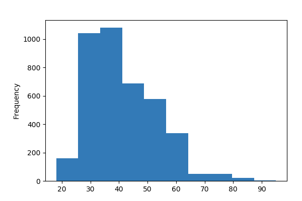

**Common Values**

| Value | Count | Frequency (%) |  |
| --- | --- | --- | --- |
| 31 | 182 | 4.5% |  |
| 32 | 177 | 4.4% |  |
| 33 | 164 | 4.1% |  |
| 34 | 163 | 4.1% |  |
| 35 | 157 | 3.9% |  |
| 36 | 154 | 3.9% |  |
| 30 | 145 | 3.6% |  |
| 37 | 140 | 3.5% |  |
| 38 | 130 | 3.2% |  |
| 39 | 126 | 3.1% |  |
| Other values (60) | 2462 | 61.6% |  |

**Extreme Values**

Minimum 5 values

| Value | Count | Frequency (%) |  |
| --- | --- | --- | --- |
| 18 | 6 | 0.1% |  |
| 19 | 9 | 0.2% |  |
| 20 | 8 | 0.2% |  |
| 21 | 12 | 0.3% |  |
| 22 | 22 | 0.5% |  |

Maximum 5 values

| Value | Count | Frequency (%) |  |
| --- | --- | --- | --- |
| 84 | 1 | 0.0% |  |
| 86 | 2 | 0.1% |  |
| 87 | 1 | 0.0% |  |
| 92 | 1 | 0.0% |  |
| 95 | 1 | 0.0% |  |

Balance  
Numeric

| Distinct count | 2178 |
| --- | --- |
| Unique (%) | 54.4% |
| Missing (%) | 0.0% |
| Missing (n) | 0 |
| Infinite (%) | 0.0% |
| Infinite (n) | 0 |

| Mean | 1532.9 |
| --- | --- |
| Minimum | -3058 |
| Maximum | 98417 |
| Zeros (%) | 7.7% |

Toggle details

**Statistics**

Quantile statistics

| Minimum | -3058 |
| --- | --- |
| 5-th percentile | -73.1 |
| Q1 | 111 |
| Median | 551.5 |
| Q3 | 1619 |
| 95-th percentile | 6290.8 |
| Maximum | 98417 |
| Range | 101475 |
| Interquartile range | 1508 |

Descriptive statistics

| Standard deviation | 3511.5 |
| --- | --- |
| Coef of variation | 2.2907 |
| Kurtosis | 185.06 |
| Mean | 1532.9 |
| MAD | 1692 |
| Skewness | 9.8779 |
| Sum | 6131749 |
| Variance | 12330000 |
| Memory size | 31.3 KiB |

**Histogram**

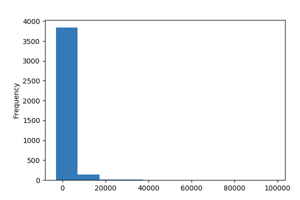

**Common Values**

| Value | Count | Frequency (%) |  |
| --- | --- | --- | --- |
| 0 | 309 | 7.7% |  |
| 1 | 14 | 0.4% |  |
| 3 | 13 | 0.3% |  |
| 2 | 13 | 0.3% |  |
| 5 | 11 | 0.3% |  |
| 6 | 9 | 0.2% |  |
| 46 | 8 | 0.2% |  |
| 53 | 8 | 0.2% |  |
| 459 | 7 | 0.2% |  |
| 238 | 7 | 0.2% |  |
| Other values (2168) | 3601 | 90.0% |  |

**Extreme Values**

Minimum 5 values

| Value | Count | Frequency (%) |  |
| --- | --- | --- | --- |
| -3058 | 1 | 0.0% |  |
| -1730 | 1 | 0.0% |  |
| -1317 | 1 | 0.0% |  |
| -1246 | 1 | 0.0% |  |
| -1206 | 1 | 0.0% |  |

Maximum 5 values

| Value | Count | Frequency (%) |  |
| --- | --- | --- | --- |
| 38279 | 1 | 0.0% |  |
| 43074 | 1 | 0.0% |  |
| 45248 | 1 | 0.0% |  |
| 52587 | 1 | 0.0% |  |
| 98417 | 1 | 0.0% |  |

CallEnd  
Categorical

| Distinct count | 3764 |
| --- | --- |
| Unique (%) | 94.1% |
| Missing (%) | 0.0% |
| Missing (n) | 0 |

| 11:27:46 | 3 |
| --- | --- |
| 10:22:30 | 3 |
| 10:52:24 | 3 |
| Other values (3761) | 3991 |

Toggle details

| Value | Count | Frequency (%) |  |
| --- | --- | --- | --- |
| 11:27:46 | 3 | 0.1% |  |
| 10:22:30 | 3 | 0.1% |  |
| 10:52:24 | 3 | 0.1% |  |
| 10:34:33 | 2 | 0.1% |  |
| 14:22:31 | 2 | 0.1% |  |
| 12:32:39 | 2 | 0.1% |  |
| 17:41:24 | 2 | 0.1% |  |
| 10:27:19 | 2 | 0.1% |  |
| 15:01:11 | 2 | 0.1% |  |
| 17:03:14 | 2 | 0.1% |  |
| Other values (3754) | 3977 | 99.4% |  |

CallStart  
Categorical

| Distinct count | 3777 |
| --- | --- |
| Unique (%) | 94.4% |
| Missing (%) | 0.0% |
| Missing (n) | 0 |

| 17:11:04 | 3 |
| --- | --- |
| 10:42:44 | 3 |
| 15:48:27 | 3 |
| Other values (3774) | 3991 |

Toggle details

| Value | Count | Frequency (%) |  |
| --- | --- | --- | --- |
| 17:11:04 | 3 | 0.1% |  |
| 10:42:44 | 3 | 0.1% |  |
| 15:48:27 | 3 | 0.1% |  |
| 13:54:34 | 3 | 0.1% |  |
| 15:27:56 | 3 | 0.1% |  |
| 11:48:25 | 3 | 0.1% |  |
| 17:02:39 | 3 | 0.1% |  |
| 10:46:54 | 2 | 0.1% |  |
| 13:36:38 | 2 | 0.1% |  |
| 11:05:37 | 2 | 0.1% |  |
| Other values (3767) | 3973 | 99.3% |  |

CarInsurance  
Boolean

| Distinct count | 2 |
| --- | --- |
| Unique (%) | 0.1% |
| Missing (%) | 0.0% |
| Missing (n) | 0 |

| Mean | 0.401 |
| --- | --- |

| 0 | 2396 |
| --- | --- |
| 1 | 1604 |

Toggle details

| Value | Count | Frequency (%) |  |
| --- | --- | --- | --- |
| 0 | 2396 | 59.9% |  |
| 1 | 1604 | 40.1% |  |

CarLoan  
Boolean

| Distinct count | 2 |
| --- | --- |
| Unique (%) | 0.1% |
| Missing (%) | 0.0% |
| Missing (n) | 0 |

| Mean | 0.133 |
| --- | --- |

| 0 | 3468 |
| --- | --- |
| 1 | 532 |

Toggle details

| Value | Count | Frequency (%) |  |
| --- | --- | --- | --- |
| 0 | 3468 | 86.7% |  |
| 1 | 532 | 13.3% |  |

Communication  
Categorical

| Distinct count | 3 |
| --- | --- |
| Unique (%) | 0.1% |
| Missing (%) | 22.6% |
| Missing (n) | 902 |

| cellular | 2831 |
| --- | --- |
| telephone | 267 |
| (Missing) | 902 |

Toggle details

| Value | Count | Frequency (%) |  |
| --- | --- | --- | --- |
| cellular | 2831 | 70.8% |  |
| telephone | 267 | 6.7% |  |
| (Missing) | 902 | 22.6% |  |

DaysPassed  
Numeric

| Distinct count | 330 |
| --- | --- |
| Unique (%) | 8.2% |
| Missing (%) | 0.0% |
| Missing (n) | 0 |
| Infinite (%) | 0.0% |
| Infinite (n) | 0 |

| Mean | 48.706 |
| --- | --- |
| Minimum | -1 |
| Maximum | 854 |
| Zeros (%) | 0.0% |

Toggle details

**Statistics**

Quantile statistics

| Minimum | -1 |
| --- | --- |
| 5-th percentile | -1 |
| Q1 | -1 |
| Median | -1 |
| Q3 | -1 |
| 95-th percentile | 316 |
| Maximum | 854 |
| Range | 855 |
| Interquartile range | 0 |

Descriptive statistics

| Standard deviation | 106.69 |
| --- | --- |
| Coef of variation | 2.1904 |
| Kurtosis | 7.5374 |
| Mean | 48.706 |
| MAD | 76.029 |
| Skewness | 2.5369 |
| Sum | 194826 |
| Variance | 11382 |
| Memory size | 31.3 KiB |

**Histogram**

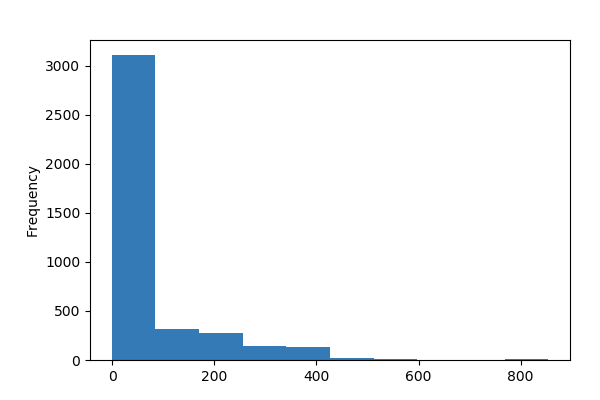

**Common Values**

| Value | Count | Frequency (%) |  |
| --- | --- | --- | --- |
| -1 | 3042 | 76.0% |  |
| 92 | 38 | 0.9% |  |
| 182 | 33 | 0.8% |  |
| 91 | 24 | 0.6% |  |
| 183 | 24 | 0.6% |  |
| 93 | 16 | 0.4% |  |
| 95 | 16 | 0.4% |  |
| 94 | 14 | 0.4% |  |
| 97 | 13 | 0.3% |  |
| 181 | 13 | 0.3% |  |
| Other values (320) | 767 | 19.2% |  |

**Extreme Values**

Minimum 5 values

| Value | Count | Frequency (%) |  |
| --- | --- | --- | --- |
| -1 | 3042 | 76.0% |  |
| 1 | 3 | 0.1% |  |
| 2 | 5 | 0.1% |  |
| 4 | 1 | 0.0% |  |
| 5 | 2 | 0.1% |  |

Maximum 5 values

| Value | Count | Frequency (%) |  |
| --- | --- | --- | --- |
| 775 | 1 | 0.0% |  |
| 779 | 1 | 0.0% |  |
| 828 | 1 | 0.0% |  |
| 842 | 1 | 0.0% |  |
| 854 | 1 | 0.0% |  |

Default  
Boolean

| Distinct count | 2 |
| --- | --- |
| Unique (%) | 0.1% |
| Missing (%) | 0.0% |
| Missing (n) | 0 |

| Mean | 0.0145 |
| --- | --- |

| 0 | 3942 |
| --- | --- |
| 1 | 58 |

Toggle details

| Value | Count | Frequency (%) |  |
| --- | --- | --- | --- |
| 0 | 3942 | 98.6% |  |
| 1 | 58 | 1.5% |  |

Education  
Categorical

| Distinct count | 4 |
| --- | --- |
| Unique (%) | 0.1% |
| Missing (%) | 4.2% |
| Missing (n) | 169 |

| secondary | 1988 |
| --- | --- |
| tertiary | 1282 |
| primary | 561 |
| (Missing) | 169 |

Toggle details

| Value | Count | Frequency (%) |  |
| --- | --- | --- | --- |
| secondary | 1988 | 49.7% |  |
| tertiary | 1282 | 32.0% |  |
| primary | 561 | 14.0% |  |
| (Missing) | 169 | 4.2% |  |

HHInsurance  
Boolean

| Distinct count | 2 |
| --- | --- |
| Unique (%) | 0.1% |
| Missing (%) | 0.0% |
| Missing (n) | 0 |

| Mean | 0.49275 |
| --- | --- |

| 0 | 2029 |
| --- | --- |
| 1 | 1971 |

Toggle details

| Value | Count | Frequency (%) |  |
| --- | --- | --- | --- |
| 0 | 2029 | 50.7% |  |
| 1 | 1971 | 49.3% |  |

Id  
Numeric

| Distinct count | 4000 |
| --- | --- |
| Unique (%) | 100.0% |
| Missing (%) | 0.0% |
| Missing (n) | 0 |
| Infinite (%) | 0.0% |
| Infinite (n) | 0 |

| Mean | 2000.5 |
| --- | --- |
| Minimum | 1 |
| Maximum | 4000 |
| Zeros (%) | 0.0% |

Toggle details

**Statistics**

Quantile statistics

| Minimum | 1 |
| --- | --- |
| 5-th percentile | 200.95 |
| Q1 | 1000.8 |
| Median | 2000.5 |
| Q3 | 3000.2 |
| 95-th percentile | 3800 |
| Maximum | 4000 |
| Range | 3999 |
| Interquartile range | 1999.5 |

Descriptive statistics

| Standard deviation | 1154.8 |
| --- | --- |
| Coef of variation | 0.57728 |
| Kurtosis | -1.2 |
| Mean | 2000.5 |
| MAD | 1000 |
| Skewness | 0 |
| Sum | 8002000 |
| Variance | 1333700 |
| Memory size | 31.3 KiB |

**Histogram**

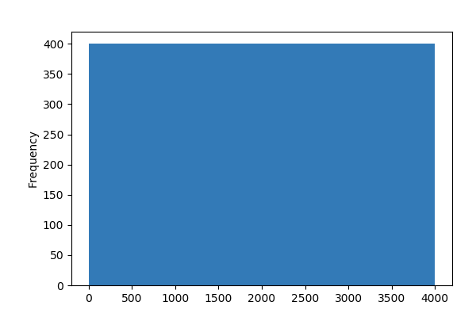

**Common Values**

| Value | Count | Frequency (%) |  |
| --- | --- | --- | --- |
| 2047 | 1 | 0.0% |  |
| 657 | 1 | 0.0% |  |
| 2732 | 1 | 0.0% |  |
| 681 | 1 | 0.0% |  |
| 2728 | 1 | 0.0% |  |
| 677 | 1 | 0.0% |  |
| 2724 | 1 | 0.0% |  |
| 673 | 1 | 0.0% |  |
| 2720 | 1 | 0.0% |  |
| 669 | 1 | 0.0% |  |
| Other values (3990) | 3990 | 99.8% |  |

**Extreme Values**

Minimum 5 values

| Value | Count | Frequency (%) |  |
| --- | --- | --- | --- |
| 1 | 1 | 0.0% |  |
| 2 | 1 | 0.0% |  |
| 3 | 1 | 0.0% |  |
| 4 | 1 | 0.0% |  |
| 5 | 1 | 0.0% |  |

Maximum 5 values

| Value | Count | Frequency (%) |  |
| --- | --- | --- | --- |
| 3996 | 1 | 0.0% |  |
| 3997 | 1 | 0.0% |  |
| 3998 | 1 | 0.0% |  |
| 3999 | 1 | 0.0% |  |
| 4000 | 1 | 0.0% |  |

Job  
Categorical

| Distinct count | 12 |
| --- | --- |
| Unique (%) | 0.3% |
| Missing (%) | 0.5% |
| Missing (n) | 19 |

| management | 893 |
| --- | --- |
| blue-collar | 759 |
| technician | 660 |
| Other values (8) | 1669 |

Toggle details

| Value | Count | Frequency (%) |  |
| --- | --- | --- | --- |
| management | 893 | 22.3% |  |
| blue-collar | 759 | 19.0% |  |
| technician | 660 | 16.5% |  |
| admin. | 459 | 11.5% |  |
| services | 330 | 8.2% |  |
| retired | 249 | 6.2% |  |
| self-employed | 140 | 3.5% |  |
| student | 131 | 3.3% |  |
| unemployed | 130 | 3.2% |  |
| entrepreneur | 121 | 3.0% |  |

LastContactDay  
Numeric

| Distinct count | 31 |
| --- | --- |
| Unique (%) | 0.8% |
| Missing (%) | 0.0% |
| Missing (n) | 0 |
| Infinite (%) | 0.0% |
| Infinite (n) | 0 |

| Mean | 15.721 |
| --- | --- |
| Minimum | 1 |
| Maximum | 31 |
| Zeros (%) | 0.0% |

Toggle details

**Statistics**

Quantile statistics

| Minimum | 1 |
| --- | --- |
| 5-th percentile | 3 |
| Q1 | 8 |
| Median | 16 |
| Q3 | 22 |
| 95-th percentile | 30 |
| Maximum | 31 |
| Range | 30 |
| Interquartile range | 14 |

Descriptive statistics

| Standard deviation | 8.4253 |
| --- | --- |
| Coef of variation | 0.53592 |
| Kurtosis | -1.0645 |
| Mean | 15.721 |
| MAD | 7.149 |
| Skewness | 0.091053 |
| Sum | 62885 |
| Variance | 70.986 |
| Memory size | 31.3 KiB |

**Histogram**

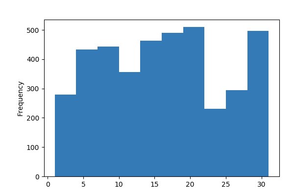

**Common Values**

| Value | Count | Frequency (%) |  |
| --- | --- | --- | --- |
| 18 | 203 | 5.1% |  |
| 20 | 196 | 4.9% |  |
| 13 | 171 | 4.3% |  |
| 30 | 167 | 4.2% |  |
| 15 | 165 | 4.1% |  |
| 17 | 163 | 4.1% |  |
| 8 | 158 | 4.0% |  |
| 19 | 158 | 4.0% |  |
| 7 | 157 | 3.9% |  |
| 21 | 156 | 3.9% |  |
| Other values (21) | 2306 | 57.6% |  |

**Extreme Values**

Minimum 5 values

| Value | Count | Frequency (%) |  |
| --- | --- | --- | --- |
| 1 | 49 | 1.2% |  |
| 2 | 138 | 3.5% |  |
| 3 | 93 | 2.3% |  |
| 4 | 136 | 3.4% |  |
| 5 | 152 | 3.8% |  |

Maximum 5 values

| Value | Count | Frequency (%) |  |
| --- | --- | --- | --- |
| 27 | 102 | 2.5% |  |
| 28 | 136 | 3.4% |  |
| 29 | 142 | 3.5% |  |
| 30 | 167 | 4.2% |  |
| 31 | 52 | 1.3% |  |

LastContactMonth  
Categorical

| Distinct count | 12 |
| --- | --- |
| Unique (%) | 0.3% |
| Missing (%) | 0.0% |
| Missing (n) | 0 |

| may | 1049 |
| --- | --- |
| jul | 573 |
| aug | 536 |
| Other values (9) | 1842 |

Toggle details

| Value | Count | Frequency (%) |  |
| --- | --- | --- | --- |
| may | 1049 | 26.2% |  |
| jul | 573 | 14.3% |  |
| aug | 536 | 13.4% |  |
| jun | 454 | 11.3% |  |
| nov | 347 | 8.7% |  |
| apr | 306 | 7.6% |  |
| feb | 262 | 6.6% |  |
| jan | 134 | 3.4% |  |
| oct | 118 | 2.9% |  |
| sep | 101 | 2.5% |  |
| Other values (2) | 120 | 3.0% |  |

Marital  
Categorical

| Distinct count | 3 |
| --- | --- |
| Unique (%) | 0.1% |
| Missing (%) | 0.0% |
| Missing (n) | 0 |

| married | 2304 |
| --- | --- |
| single | 1213 |
| divorced | 483 |

Toggle details

| Value | Count | Frequency (%) |  |
| --- | --- | --- | --- |
| married | 2304 | 57.6% |  |
| single | 1213 | 30.3% |  |
| divorced | 483 | 12.1% |  |

NoOfContacts  
Numeric

| Distinct count | 35 |
| --- | --- |
| Unique (%) | 0.9% |
| Missing (%) | 0.0% |
| Missing (n) | 0 |
| Infinite (%) | 0.0% |
| Infinite (n) | 0 |

| Mean | 2.6073 |
| --- | --- |
| Minimum | 1 |
| Maximum | 43 |
| Zeros (%) | 0.0% |

Toggle details

**Statistics**

Quantile statistics

| Minimum | 1 |
| --- | --- |
| 5-th percentile | 1 |
| Q1 | 1 |
| Median | 2 |
| Q3 | 3 |
| 95-th percentile | 7 |
| Maximum | 43 |
| Range | 42 |
| Interquartile range | 2 |

Descriptive statistics

| Standard deviation | 3.0642 |
| --- | --- |
| Coef of variation | 1.1753 |
| Kurtosis | 40.191 |
| Mean | 2.6073 |
| MAD | 1.6835 |
| Skewness | 5.2413 |
| Sum | 10429 |
| Variance | 9.3893 |
| Memory size | 31.3 KiB |

**Histogram**

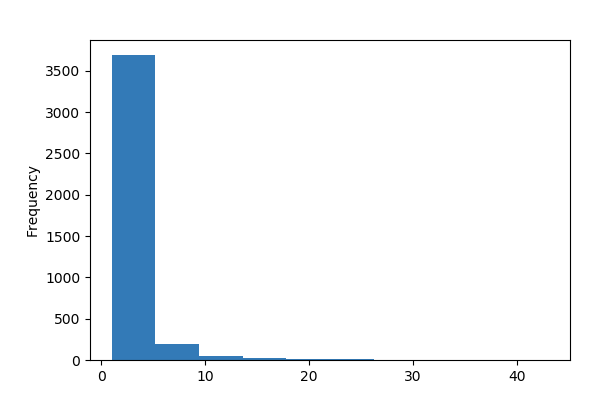

**Common Values**

| Value | Count | Frequency (%) |  |
| --- | --- | --- | --- |
| 1 | 1685 | 42.1% |  |
| 2 | 1085 | 27.1% |  |
| 3 | 516 | 12.9% |  |
| 4 | 237 | 5.9% |  |
| 5 | 166 | 4.2% |  |
| 6 | 88 | 2.2% |  |
| 7 | 49 | 1.2% |  |
| 8 | 41 | 1.0% |  |
| 9 | 20 | 0.5% |  |
| 10 | 18 | 0.4% |  |
| Other values (25) | 95 | 2.4% |  |

**Extreme Values**

Minimum 5 values

| Value | Count | Frequency (%) |  |
| --- | --- | --- | --- |
| 1 | 1685 | 42.1% |  |
| 2 | 1085 | 27.1% |  |
| 3 | 516 | 12.9% |  |
| 4 | 237 | 5.9% |  |
| 5 | 166 | 4.2% |  |

Maximum 5 values

| Value | Count | Frequency (%) |  |
| --- | --- | --- | --- |
| 32 | 1 | 0.0% |  |
| 34 | 1 | 0.0% |  |
| 38 | 1 | 0.0% |  |
| 41 | 1 | 0.0% |  |
| 43 | 1 | 0.0% |  |

Outcome  
Categorical

| Distinct count | 4 |
| --- | --- |
| Unique (%) | 0.1% |
| Missing (%) | 76.0% |
| Missing (n) | 3042 |

| failure | 437 |
| --- | --- |
| success | 326 |
| other | 195 |
| (Missing) | 3042 |

Toggle details

| Value | Count | Frequency (%) |  |
| --- | --- | --- | --- |
| failure | 437 | 10.9% |  |
| success | 326 | 8.2% |  |
| other | 195 | 4.9% |  |
| (Missing) | 3042 | 76.0% |  |

PrevAttempts  
Numeric

| Distinct count | 20 |
| --- | --- |
| Unique (%) | 0.5% |
| Missing (%) | 0.0% |
| Missing (n) | 0 |
| Infinite (%) | 0.0% |
| Infinite (n) | 0 |

| Mean | 0.7175 |
| --- | --- |
| Minimum | 0 |
| Maximum | 58 |
| Zeros (%) | 76.0% |

Toggle details

**Statistics**

Quantile statistics

| Minimum | 0 |
| --- | --- |
| 5-th percentile | 0 |
| Q1 | 0 |
| Median | 0 |
| Q3 | 0 |
| 95-th percentile | 4 |
| Maximum | 58 |
| Range | 58 |
| Interquartile range | 0 |

Descriptive statistics

| Standard deviation | 2.0786 |
| --- | --- |
| Coef of variation | 2.8971 |
| Kurtosis | 170.04 |
| Mean | 0.7175 |
| MAD | 1.0913 |
| Skewness | 8.9327 |
| Sum | 2870 |
| Variance | 4.3208 |
| Memory size | 31.3 KiB |

**Histogram**

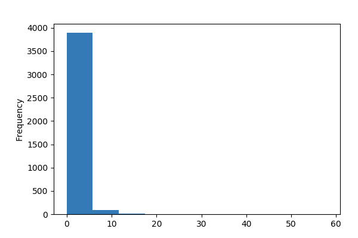

**Common Values**

| Value | Count | Frequency (%) |  |
| --- | --- | --- | --- |
| 0 | 3042 | 76.0% |  |
| 1 | 335 | 8.4% |  |
| 2 | 251 | 6.3% |  |
| 3 | 125 | 3.1% |  |
| 4 | 79 | 2.0% |  |
| 5 | 60 | 1.5% |  |
| 6 | 25 | 0.6% |  |
| 7 | 21 | 0.5% |  |
| 8 | 18 | 0.4% |  |
| 10 | 10 | 0.2% |  |
| Other values (10) | 34 | 0.9% |  |

**Extreme Values**

Minimum 5 values

| Value | Count | Frequency (%) |  |
| --- | --- | --- | --- |
| 0 | 3042 | 76.0% |  |
| 1 | 335 | 8.4% |  |
| 2 | 251 | 6.3% |  |
| 3 | 125 | 3.1% |  |
| 4 | 79 | 2.0% |  |

Maximum 5 values

| Value | Count | Frequency (%) |  |
| --- | --- | --- | --- |
| 18 | 1 | 0.0% |  |
| 19 | 4 | 0.1% |  |
| 23 | 1 | 0.0% |  |
| 30 | 1 | 0.0% |  |
| 58 | 1 | 0.0% |  |

Correlations

Sample

|  | Id | Age | Job | Marital | Education | Default | Balance | HHInsurance | CarLoan | Communication | LastContactDay | LastContactMonth | NoOfContacts | DaysPassed | PrevAttempts | Outcome | CallStart | CallEnd | CarInsurance |
| --- | --- | --- | --- | --- | --- | --- | --- | --- | --- | --- | --- | --- | --- | --- | --- | --- | --- | --- | --- |
| 0 | 1 | 32 | management | single | tertiary | 0 | 1218 | 1 | 0 | telephone | 28 | jan | 2 | -1 | 0 | NaN | 13:45:20 | 13:46:30 | 0 |
| 1 | 2 | 32 | blue-collar | married | primary | 0 | 1156 | 1 | 0 | NaN | 26 | may | 5 | -1 | 0 | NaN | 14:49:03 | 14:52:08 | 0 |
| 2 | 3 | 29 | management | single | tertiary | 0 | 637 | 1 | 0 | cellular | 3 | jun | 1 | 119 | 1 | failure | 16:30:24 | 16:36:04 | 1 |
| 3 | 4 | 25 | student | single | primary | 0 | 373 | 1 | 0 | cellular | 11 | may | 2 | -1 | 0 | NaN | 12:06:43 | 12:20:22 | 1 |
| 4 | 5 | 30 | management | married | tertiary | 0 | 2694 | 0 | 0 | cellular | 3 | jun | 1 | -1 | 0 | NaN | 14:35:44 | 14:38:56 | 0 |

```python
pp.ProfileReport(Insurance_Data)
```

## EDA

### Let's check the summary fo data

```python
# Let's look at some statistical information about our dataframe.
Insurance_Data.describe()
```

|  | Id | Age | Default | Balance | HHInsurance | CarLoan | LastContactDay | NoOfContacts | DaysPassed | PrevAttempts | CarInsurance |
| --- | --- | --- | --- | --- | --- | --- | --- | --- | --- | --- | --- |
| count | 4000.000000 | 4000.000000 | 4000.000000 | 4000.000000 | 4000.00000 | 4000.000000 | 4000.000000 | 4000.000000 | 4000.000000 | 4000.000000 | 4000.000000 |
| mean | 2000.500000 | 41.214750 | 0.014500 | 1532.937250 | 0.49275 | 0.133000 | 15.721250 | 2.607250 | 48.706500 | 0.717500 | 0.401000 |
| std | 1154.844867 | 11.550194 | 0.119555 | 3511.452489 | 0.50001 | 0.339617 | 8.425307 | 3.064204 | 106.685385 | 2.078647 | 0.490162 |
| min | 1.000000 | 18.000000 | 0.000000 | -3058.000000 | 0.00000 | 0.000000 | 1.000000 | 1.000000 | -1.000000 | 0.000000 | 0.000000 |
| 25% | 1000.750000 | 32.000000 | 0.000000 | 111.000000 | 0.00000 | 0.000000 | 8.000000 | 1.000000 | -1.000000 | 0.000000 | 0.000000 |
| 50% | 2000.500000 | 39.000000 | 0.000000 | 551.500000 | 0.00000 | 0.000000 | 16.000000 | 2.000000 | -1.000000 | 0.000000 | 0.000000 |
| 75% | 3000.250000 | 49.000000 | 0.000000 | 1619.000000 | 1.00000 | 0.000000 | 22.000000 | 3.000000 | -1.000000 | 0.000000 | 1.000000 |
| max | 4000.000000 | 95.000000 | 1.000000 | 98417.000000 | 1.00000 | 1.000000 | 31.000000 | 43.000000 | 854.000000 | 58.000000 | 1.000000 |

```python
# This is how we can get summary for the categorical data
Insurance_Data.describe(include=np.object)
```

|  | Job | Marital | Education | Communication | LastContactMonth | Outcome | CallStart | CallEnd |
| --- | --- | --- | --- | --- | --- | --- | --- | --- |
| count | 3981 | 4000 | 3831 | 3098 | 4000 | 958 | 4000 | 4000 |
| unique | 11 | 3 | 3 | 2 | 12 | 3 | 3777 | 3764 |
| top | management | married | secondary | cellular | may | failure | 17:11:04 | 11:27:46 |
| freq | 893 | 2304 | 1988 | 2831 | 1049 | 437 | 3 | 3 |

### Univariate Analysis

**Lets analyse the data w.r.t our Target variable**

```python
Target = 'CarInsurance'
pd.crosstab(Insurance_Data[Target], columns='N', normalize=True)
```

| col_0 CarInsurance | N |
| --- | --- |
| 0 | 0.599 |
| 1 | 0.401 |

**The data seems to be quiet good as we have approx. 40% of 1's in our data**

### Visualising Data - Bivariate

```python
Insurance_Data.head()
```

|  | Id | Age | Job | Marital | Education | Default | Balance | HHInsurance | CarLoan | Communication | LastContactDay | LastContactMonth | NoOfContacts | DaysPassed | PrevAttempts | Outcome | CallStart | CallEnd | CarInsurance |
| --- | --- | --- | --- | --- | --- | --- | --- | --- | --- | --- | --- | --- | --- | --- | --- | --- | --- | --- | --- |
| 0 | 1 | 32 | management | single | tertiary | 0 | 1218 | 1 | 0 | telephone | 28 | jan | 2 | -1 | 0 | NaN | 13:45:20 | 13:46:30 | 0 |
| 1 | 2 | 32 | blue-collar | married | primary | 0 | 1156 | 1 | 0 | NaN | 26 | may | 5 | -1 | 0 | NaN | 14:49:03 | 14:52:08 | 0 |
| 2 | 3 | 29 | management | single | tertiary | 0 | 637 | 1 | 0 | cellular | 3 | jun | 1 | 119 | 1 | failure | 16:30:24 | 16:36:04 | 1 |
| 3 | 4 | 25 | student | single | primary | 0 | 373 | 1 | 0 | cellular | 11 | may | 2 | -1 | 0 | NaN | 12:06:43 | 12:20:22 | 1 |
| 4 | 5 | 30 | management | married | tertiary | 0 | 2694 | 0 | 0 | cellular | 3 | jun | 1 | -1 | 0 | NaN | 14:35:44 | 14:38:56 | 0 |

```python
num_cols = Insurance_Data.select_dtypes(include=[np.number]).columns.tolist()
non_num_cols = Insurance_Data.select_dtypes(exclude=[np.number]).columns.tolist()
```

```python
# Lets drop columns which we will not use
num_cols = Insurance_Data.drop(['Id', 'CarInsurance'],axis=1).select_dtypes(include=[np.number]).columns.tolist()
non_num_cols = Insurance_Data.drop(['CallStart', 'CallEnd'],axis=1).select_dtypes(exclude=[np.number]).columns.tolist()
```

```python
print('Numeric Columns \n', num_cols)
print('Non-Numeric Columns \n', non_num_cols)
```

```
Numeric Columns
 ['Age', 'Default', 'Balance', 'HHInsurance', 'CarLoan', 'LastContactDay', 'NoOfContacts', 'DaysPassed', 'PrevAttempts']
Non-Numeric Columns
 ['Job', 'Marital', 'Education', 'Communication', 'LastContactMonth', 'Outcome']
```

```
Age                    AxesSubplot(0.1,0.679412;0.363636x0.220588)
Balance           AxesSubplot(0.536364,0.679412;0.363636x0.220588)
DaysPassed             AxesSubplot(0.1,0.414706;0.363636x0.220588)
LastContactDay    AxesSubplot(0.536364,0.414706;0.363636x0.220588)
NoOfContacts               AxesSubplot(0.1,0.15;0.363636x0.220588)
PrevAttempts          AxesSubplot(0.536364,0.15;0.363636x0.220588)
dtype: object
```

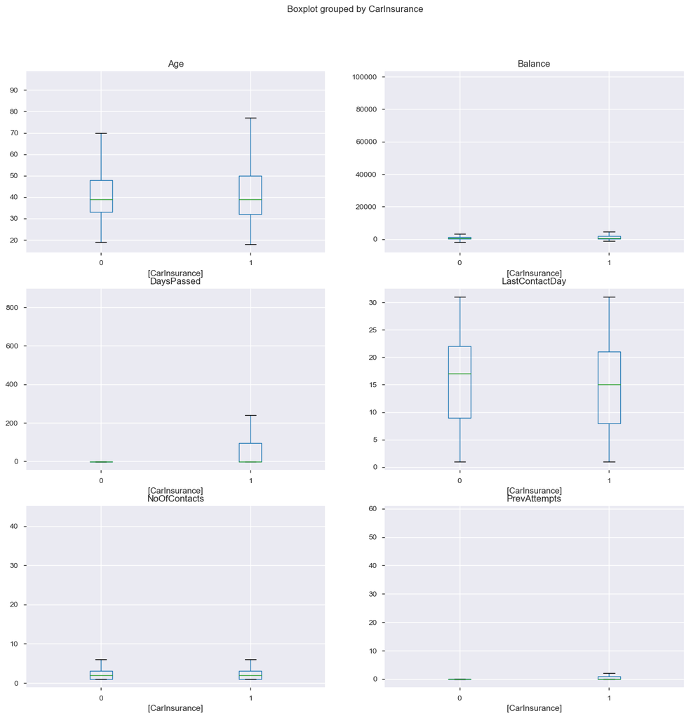

```python
# Lets drop CarLoan, HHInsurance, Default from the numeric columns as these are dummies
num_cols_viz = ['DaysPassed', 'Age', 'NoOfContacts', 'PrevAttempts', 'LastContactDay', 'Balance']

fig, axes = plt.subplots(3,2,sharex=False,sharey=False, figsize=(15,15))
Insurance_Data.loc[:,[Target]+num_cols_viz].boxplot(by=Target, ax=axes,return_type='axes')
```

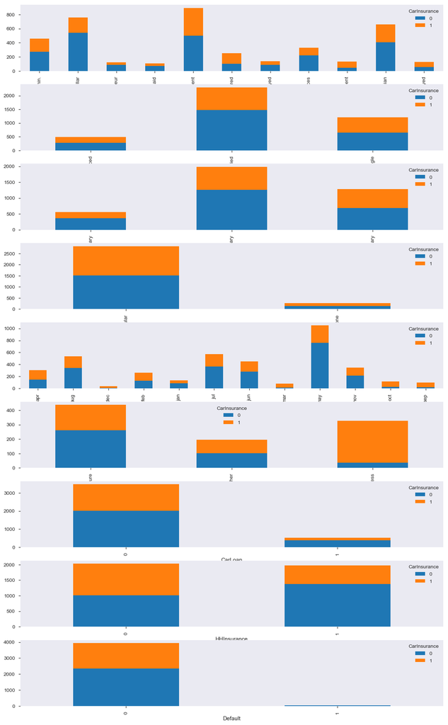

```python
non_num_cols_viz = non_num_cols+['CarLoan', 'HHInsurance', 'Default']
fig, axes = plt.subplots(len(non_num_cols_viz),sharex=False,sharey=False, figsize=(15,50))
for i in range(len(non_num_cols_viz)):
    pd.crosstab(Insurance_Data[non_num_cols_viz[i]], Insurance_Data[Target]).plot(kind='bar',
                                                                                  stacked=True,
                                                                                  grid=False,
                                                                                  ax=axes[i],
                                                                                  rot=0)
```

- The JobType='Retired' seem to have higher chance of buying insurance
- The Communication='cellular' seem to best way to reach out for carinsurance

## Check for Missing Values

```python
Insurance_Data.isnull().sum()
```

```
Id                     0
Age                    0
Job                   19
Marital                0
Education            169
Default                0
Balance                0
HHInsurance            0
CarLoan                0
Communication        902
LastContactDay         0
LastContactMonth       0
NoOfContacts           0
DaysPassed             0
PrevAttempts           0
Outcome             3042
CallStart              0
CallEnd                0
CarInsurance           0
dtype: int64
```

**Looks like variables Job, Education, Communication & Outcome have missing values. Lets analyse them and treat them accordingly**

### Missing Values - Job

```python
Insurance_Data_Org = Insurance_Data.copy()
```

```python
Insurance_Data['Job'].value_counts(dropna=False)
```

```
management       893
blue-collar      759
technician       660
admin.           459
services         330
retired          249
self-employed    140
student          131
unemployed       130
entrepreneur     121
housemaid        109
NaN               19
Name: Job, dtype: int64
```

Lets replace the missing with None. This will help us in handling missing values in future as well.

```python
Insurance_Data['Job'] = Insurance_Data['Job'].fillna('None')
Insurance_Data['Job'].isnull().sum()
```

```
0
```

### Missing Values - Education

```python
# Fill missing education with the most common education level by job type
Insurance_Data['Education'].value_counts()

# Create job-education level mode mapping
edu_mode=[]

# What are different Job Types
job_types = Insurance_Data.Job.value_counts().index

# Checking which job is most
Insurance_Data['Job'].value_counts()
```

```
management       893
blue-collar      759
technician       660
admin.           459
services         330
retired          249
self-employed    140
student          131
unemployed       130
entrepreneur     121
housemaid        109
None              19
Name: Job, dtype: int64
```

```python
# Now according to the job type we will crate a mapping where the job and mode of education is there.
# It means when there are many people in the managment job then most of them are in which education.
# We can find that in below mapping

for job in job_types:
    mode = Insurance_Data[Insurance_Data.Job==job]['Education'].value_counts().nlargest(1).index
    edu_mode = np.append(edu_mode,mode)
edu_map=pd.Series(edu_mode,index=Insurance_Data.Job.value_counts().index)

edu_map
```

```
management        tertiary
blue-collar      secondary
technician       secondary
admin.           secondary
services         secondary
retired          secondary
self-employed     tertiary
student          secondary
unemployed       secondary
entrepreneur      tertiary
housemaid          primary
None             secondary
dtype: object
```

```python
# Apply the mapping to missing eductaion obs. We will replace education now by jobs value
for j in job_types:
    Insurance_Data.loc[(Insurance_Data['Education'].isnull()) & (Insurance_Data['Job']==j),'Education'] = edu_map.loc[edu_map.index==j][0]

# For those who are not getting mapped we will create a new category as None
Insurance_Data['Education'].fillna('None',inplace=True)
```

### Missing Value - Communication

```python
# Fill missing communication with none
Insurance_Data['Communication'].value_counts(dropna=False)
```

```
cellular     2831
NaN           902
telephone     267
Name: Communication, dtype: int64
```

```python
Insurance_Data['Communication'] = Insurance_Data['Communication'].fillna('None')
```

### Missing Value - Outcome

```python
# Check for missing value in Outcome
Insurance_Data['Outcome'].value_counts(dropna=False)
```

```
NaN        3042
failure     437
success     326
other       195
Name: Outcome, dtype: int64
```

```python
# Fill missing outcome as not in previous campaign, we are adding one category to Outcome
# We will add category if the value of DaysPassed is -1
# Can you do it other ways.. yes this is one way of doing you can do it other ways also.

Insurance_Data.loc[Insurance_Data['DaysPassed']==-1,'Outcome']='NoPrev'
Insurance_Data['Outcome'].value_counts(dropna=False)
```

```
NoPrev     3042
failure     437
success     326
other       195
Name: Outcome, dtype: int64
```

```python
# Check if we have any missing values left
Insurance_Data.isnull().sum()
```

```
Id                  0
Age                 0
Job                 0
Marital             0
Education           0
Default             0
Balance             0
HHInsurance         0
CarLoan             0
Communication       0
LastContactDay      0
LastContactMonth    0
NoOfContacts        0
DaysPassed          0
PrevAttempts        0
Outcome             0
CallStart           0
CallEnd             0
CarInsurance        0
dtype: int64
```

**Now we do not have any missing values**

## Create Model Dataset

```python
Insurance_Data_num = Insurance_Data[num_cols+['Id', 'CarInsurance']]
```

```python
# Categorical columns data
Insurance_Data_cat = Insurance_Data[non_num_cols]
non_num_cols
```

```
['Job', 'Marital', 'Education', 'Communication', 'LastContactMonth', 'Outcome']
```

```python
# Create dummies
Insurance_Data_cat_dummies = pd.get_dummies(Insurance_Data_cat)
print(Insurance_Data_cat_dummies.shape)
Insurance_Data_cat_dummies.head()
```

```
(4000, 37)
```

|  | Job_None | Job_admin. | Job_blue-collar | Job_entrepreneur | Job_housemaid | Job_management | Job_retired | Job_self-employed | Job_services | Job_student | ... | LastContactMonth_jun | LastContactMonth_mar | LastContactMonth_may | LastContactMonth_nov | LastContactMonth_oct | LastContactMonth_sep | Outcome_NoPrev | Outcome_failure | Outcome_other | Outcome_success |
| --- | --- | --- | --- | --- | --- | --- | --- | --- | --- | --- | --- | --- | --- | --- | --- | --- | --- | --- | --- | --- | --- |
| 0 | 0 | 0 | 0 | 0 | 0 | 1 | 0 | 0 | 0 | 0 | ... | 0 | 0 | 0 | 0 | 0 | 0 | 1 | 0 | 0 | 0 |
| 1 | 0 | 0 | 1 | 0 | 0 | 0 | 0 | 0 | 0 | 0 | ... | 0 | 0 | 1 | 0 | 0 | 0 | 1 | 0 | 0 | 0 |
| 2 | 0 | 0 | 0 | 0 | 0 | 1 | 0 | 0 | 0 | 0 | ... | 1 | 0 | 0 | 0 | 0 | 0 | 0 | 1 | 0 | 0 |
| 3 | 0 | 0 | 0 | 0 | 0 | 0 | 0 | 0 | 0 | 1 | ... | 0 | 0 | 1 | 0 | 0 | 0 | 1 | 0 | 0 | 0 |
| 4 | 0 | 0 | 0 | 0 | 0 | 1 | 0 | 0 | 0 | 0 | ... | 1 | 0 | 0 | 0 | 0 | 0 | 1 | 0 | 0 | 0 |

5 rows × 37 columns

```python
Insurance_Data_final = pd.concat([Insurance_Data_num, Insurance_Data_cat_dummies], axis=1)
print(Insurance_Data_final.shape)
Insurance_Data_final.head()
```

```
(4000, 48)
```

|  | Age | Default | Balance | HHInsurance | CarLoan | LastContactDay | NoOfContacts | DaysPassed | PrevAttempts | Id | ... | LastContactMonth_jun | LastContactMonth_mar | LastContactMonth_may | LastContactMonth_nov | LastContactMonth_oct | LastContactMonth_sep | Outcome_NoPrev | Outcome_failure | Outcome_other | Outcome_success |
| --- | --- | --- | --- | --- | --- | --- | --- | --- | --- | --- | --- | --- | --- | --- | --- | --- | --- | --- | --- | --- | --- |
| 0 | 32 | 0 | 1218 | 1 | 0 | 28 | 2 | -1 | 0 | 1 | ... | 0 | 0 | 0 | 0 | 0 | 0 | 1 | 0 | 0 | 0 |
| 1 | 32 | 0 | 1156 | 1 | 0 | 26 | 5 | -1 | 0 | 2 | ... | 0 | 0 | 1 | 0 | 0 | 0 | 1 | 0 | 0 | 0 |
| 2 | 29 | 0 | 637 | 1 | 0 | 3 | 1 | 119 | 1 | 3 | ... | 1 | 0 | 0 | 0 | 0 | 0 | 0 | 1 | 0 | 0 |
| 3 | 25 | 0 | 373 | 1 | 0 | 11 | 2 | -1 | 0 | 4 | ... | 0 | 0 | 1 | 0 | 0 | 0 | 1 | 0 | 0 | 0 |
| 4 | 30 | 0 | 2694 | 0 | 0 | 3 | 1 | -1 | 0 | 5 | ... | 1 | 0 | 0 | 0 | 0 | 0 | 1 | 0 | 0 | 0 |

5 rows × 48 columns

```python
# Checking if there are missing values before we run model
Insurance_Data_final.isnull().sum(axis = 0)
```

```
Age                        0
Default                    0
Balance                    0
HHInsurance                0
CarLoan                    0
LastContactDay             0
NoOfContacts               0
DaysPassed                 0
PrevAttempts               0
Id                         0
CarInsurance               0
Job_None                   0
Job_admin.                 0
Job_blue-collar            0
Job_entrepreneur           0
Job_housemaid              0
Job_management             0
Job_retired                0
Job_self-employed          0
Job_services               0
Job_student                0
Job_technician             0
Job_unemployed             0
Marital_divorced           0
Marital_married            0
Marital_single             0
Education_primary          0
Education_secondary        0
Education_tertiary         0
Communication_None         0
Communication_cellular     0
Communication_telephone    0
LastContactMonth_apr       0
LastContactMonth_aug       0
LastContactMonth_dec       0
LastContactMonth_feb       0
LastContactMonth_jan       0
LastContactMonth_jul       0
LastContactMonth_jun       0
LastContactMonth_mar       0
LastContactMonth_may       0
LastContactMonth_nov       0
LastContactMonth_oct       0
LastContactMonth_sep       0
Outcome_NoPrev             0
Outcome_failure            0
Outcome_other              0
Outcome_success            0
dtype: int64
```

## Split Data

```python
train_df = Insurance_Data_final.drop(['Id', 'CarInsurance'], axis=1)
train_label = Insurance_Data_final['CarInsurance']
```

```python
#random_state is the seed used by the random number generator. It can be any integer.
# Train test split
X_train, X_test, y_train, y_test = train_test_split(train_df, train_label, train_size=0.7 , random_state=100)
```

```python
print('Train shape - ', X_train.shape)
print('Test shape  - ', X_test.shape)
```

```
Train shape -  (2800, 46)
Test shape  -  (1200, 46)
```

## Model

```python
# Define Model parameters to tune
model_parameters = {
        'kernel':['linear', 'rbf', 'poly'],
        'C':[1, 10, 100, 1000],
        'class_weight': ['balanced'],
        'gamma': [0.0001, 0.001]
    }
```

```python
# Gridsearch the parameters to find the best parameters.
model = SVC(probability=True)  # Support vector classifier

gscv = GridSearchCV(estimator=model,
                    param_grid=model_parameters,
                    cv=5,
                    verbose=1,
                    n_jobs=-1,
                    scoring='f1')

gscv.fit(X_train, y_train)
```

```python
print('The best parameter are -', gscv.best_params_)
```

[output not shown]

```python
# Re-fit the model with the best parameters
final_mod = SVC(**gscv.best_params_)
final_mod.fit(X_train, y_train)
```

```python
# Prediction
train_pred = final_mod.predict(X_train)
test_pred = final_mod.predict(X_test)
```

```python
print('Classification report for train data is : \n',
      classification_report(y_train, train_pred))
print('Classification report for test data is : \n',
      classification_report(y_test, test_pred))
```

[output not shown]

```python
# Save the variables used in the model as it will be required in future for new datasets prediction
final_mod.variables = X_train.columns
```

## Save Best Model

```python
joblib.dump(final_mod, 'best_model.joblib')
```

### Evaluation

```python
# Generate ROC
plt.subplots(figsize=(10, 5))
train_prob = final_mod.predict_proba(X_train)[:, 1]
test_prob = final_mod.predict_proba(X_test)[:, 1]

plot_roc_curve(y_train, train_prob,
               y_test, test_prob)
```

[output not shown]

## Apply Model on Test Data

**This part shows how to use the saved model on new datasets which would come in future for scoring**

```python
# Load the saved model

best_model = joblib.load('best_model.joblib')
```

```python
# Load the test data
Insurance_test = pd.read_csv('../input/carInsurance_test.csv')
print('Test Data Shape  - ', Insurance_test.shape)
Insurance_test.head()
```

[output not shown]

```python
# Handle missing values on the test data
# The function takes the dataframe and does the same preprocessing that was done for train data

def handle_missing_values(df):
    #Job
    df['Job'] = df['Job'].fillna('None')

    #Education
    # Apply the mapping to missing eductaion obs. We will replace education now by jobs value
    for j in job_types:
        df.loc[(df['Education'].isnull()) & (df['Job']==j),'Education'] = edu_map.loc[edu_map.index==j][0]

    # For those who are not getting mapped we will create a new category as None
    df['Education'] = df['Education'].fillna('None')

    #Communication
    df['Communication'] = df['Communication'].fillna('None')

    #Outcome
    df.loc[df['DaysPassed']==-1,'Outcome']='NoPrev'

    return df
```

```python
Insurance_test_Org = Insurance_test.copy()
```

```python
# Handle the missing values the same we had done for Train
Insurance_test = handle_missing_values(Insurance_test)
```

```python
Insurance_test.isnull().sum()
```

```python
# Convert Categorical to dummies
dummy_cols = pd.get_dummies(Insurance_test[non_num_cols])
dummy_cols.head()
```

[output not shown]

```python
# Append the columns
new_data = pd.concat([Insurance_test[num_cols], dummy_cols], axis=1)
print(new_data.shape)
new_data.head()
```

[output not shown]

```python
# Check if all the variables of train are present in test
# Variables in model
best_model.variables
```

```python
# Variables missing in test data. This happens sometimes because of some categories not present in the new data
vars_missing = list(set(best_model.variables) - set(new_data.columns))
vars_missing
```

```python
# Create the missing columns in the dataset and fill them with 0
# This will create columns bonly if there are missing values
for i in vars_missing:
    new_data[i] = 0

print(new_data.shape)
new_data.head()
```

```python
# Get the new dataset in the same order of the variables used in train
new_data_final = new_data[best_model.variables]
new_data.head()
```

```python
# Predict on the new data
new_data_final['Predicted'] = best_model.predict(new_data_final)
new_data_final.head()
```

```python
# Export the results
new_data_final.to_csv('Predicted.csv', index=False)
```